# What is Pandas?

**1.Pandas is a Python library used for working with data sets.**

**2.It has functions for analyzing, cleaning, exploring, and manipulating data.**

**3.The name "Pandas" has a reference to both "Panel Data", and "Python Data Analysis" and was created by Wes McKinney in 2008.**

# Why Use Pandas?

**1.Pandas allows us to analyze big data and make conclusions based on statistical theories.**

**2.Pandas can clean messy data sets, and make them readable and relevant.**

**3.Relevant data is very important in data science.**

```python
import pandas as pd
import numpy as np
```

**Pandas Series with Python Lists**

A Series is a one-dimensional array-like object containing a sequence of values (of similar types to NumPy types) of the same type and an associated array of data labels, called its index.

**note:**

Numpy arrays are homogeneous and optimized for numerical operations, while Pandas Series are heterogeneous, offering flexibility for data handling.

```python
lst = [1,2,3,4,5,6]
print(lst)
```

```
[1, 2, 3, 4, 5, 6]
```

```python
series = pd.Series(lst)
print(series)

for item in series:
    print(item)
print(series[3])
print(type(series))
```

```
0    1
1    2
2    3
3    4
4    5
5    6
dtype: int64
1
2
3
4
5
6
4
<class 'pandas.core.series.Series'>
```

```python
idx=[10,11,12,13,14]
series = pd.Series(['p','q','r','s','t',], index = idx)
i=0
for i in idx:
    print(series[i])
```

```
p
q
r
s
t
```

```python
series.index
```

```
Int64Index([10, 11, 12, 13, 14], dtype='int64')
```

```python
#idx=[10,11,12,13,14]
series = pd.Series(['p','q','r','s','t',])
```

```python
series.index
```

```
RangeIndex(start=0, stop=5, step=1)
```

```python
series.array
```

```
<PandasArray>
['p', 'q', 'r', 's', 't']
Length: 5, dtype: object
```

```python
scalar_series = pd.Series(0.5)
scalar_series
```

```
0    0.5
dtype: float64
```

```python
scalar_series = pd.Series(0.5, index = [1,2,3])
scalar_series
```

```
1    0.5
2    0.5
3    0.5
dtype: float64
```

**Pandas Series with Python Dictionary**

```python
dict_series = pd.Series({'p':1, 'q':2, 'r':3, 's':4, 't':5})
dict_series
```

```
p    1
q    2
r    3
s    4
t    5
dtype: int64
```

```python
dict_series['q']
```

```
2
```

```python
min(dict_series)
```

```
1
```

```python
dict_series = pd.Series({'p':[1,5,6], 'q':[2,6,7], 'r':[3,9,0], 's':[4,4,5], 't':[5,1,2]})
print(dict_series)

for item in dict_series:
    print(item)
    for elm in item:
        print(elm)
```

```
p    [1, 5, 6]
q    [2, 6, 7]
r    [3, 9, 0]
s    [4, 4, 5]
t    [5, 1, 2]
dtype: object
[1, 5, 6]
1
5
6
[2, 6, 7]
2
6
7
[3, 9, 0]
3
9
0
[4, 4, 5]
4
4
5
[5, 1, 2]
5
1
2
```

```python
b = pd.Series(['p','q','r','s','t'], index = [19,11,12,13,14])
b.append(pd.Series({60:'A'}))
```

```
19    p
11    q
12    r
13    s
14    t
60    A
dtype: object
```

**Pandas DataFrame**

```python
df = pd.DataFrame()
print(df)
```

```
Empty DataFrame
Columns: []
Index: []
```

**DataFrame Using List**

```python
lst = [1,2,3,4,5]
df = pd.DataFrame(lst)
print(df)
```

```
   0
0  1
1  2
2  3
3  4
4  5
```

```python
lst = [[1,2,3,4,5], [11,12,13,14,9,78,15]]
df = pd.DataFrame(lst)
df
```

|  | 0 | 1 | 2 | 3 | 4 | 5 | 6 |
| --- | --- | --- | --- | --- | --- | --- | --- |
| 0 | 1 | 2 | 3 | 4 | 5 | NaN | NaN |
| 1 | 11 | 12 | 13 | 14 | 9 | 78.0 | 15.0 |

```python
a = [{'a':5, 'b':7, 'c':9, 'd':2},
     {'g':4, 'b':8, 'c':19, 'd':12}]        # Dictionary Keys represents Column names

df = pd.DataFrame(a)
df
```

|  | a | b | c | d | g |
| --- | --- | --- | --- | --- | --- |
| 0 | 5.0 | 7 | 9 | 2 | NaN |
| 1 | NaN | 8 | 19 | 12 | 4.0 |

```python
b = {'RollNo.':pd.Series([1,2,3,4,5]),
    'Maths':pd.Series([67,89,23,90,56]),
    'Physics':pd.Series([12,98,44,90,78])}

df = pd.DataFrame(b)
print(df)
print(df.dtypes)
print(df['Physics'])
print(df['Maths'].dtype)
```

```
   RollNo.  Maths  Physics
0        1     67       12
1        2     89       98
2        3     23       44
3        4     90       90
4        5     56       78
RollNo.    int64
Maths      int64
Physics    int64
dtype: object
0    12
1    98
2    44
3    90
4    78
Name: Physics, dtype: int64
int64
```

**Reading CSV (Common Separated Values) as DataFrames**

```python
#from google.colab import drive
```

```python
#drive.mount(r'/content/drive')
```

```python
from glob import glob
files=glob(r'C:\Users\rahma\Desktop\Data Mining 2024-2025\Section 2\Data Sets\*')
files
```

```
['C:\\Users\\rahma\\Desktop\\Data Mining 2024-2025\\Section 2\\Data Sets\\heart.csv',
 'C:\\Users\\rahma\\Desktop\\Data Mining 2024-2025\\Section 2\\Data Sets\\Restaurant.csv',
 'C:\\Users\\rahma\\Desktop\\Data Mining 2024-2025\\Section 2\\Data Sets\\Salary_Data.csv',
 'C:\\Users\\rahma\\Desktop\\Data Mining 2024-2025\\Section 2\\Data Sets\\sample.csv',
 'C:\\Users\\rahma\\Desktop\\Data Mining 2024-2025\\Section 2\\Data Sets\\sample2.csv']
```

```python
df = pd.read_csv(r'C:\Users\rahma\Desktop\Data Mining 2024-2025\Section 2\Data Sets\Salary_Data.csv')
df
```

|  | YearsExperience | Salary |
| --- | --- | --- |
| 0 | 1.1 | 39343.0 |
| 1 | 1.3 | 46205.0 |
| 2 | 1.5 | 37731.0 |
| 3 | 2.0 | 43525.0 |
| 4 | 2.2 | 39891.0 |
| 5 | 2.9 | 56642.0 |
| 6 | 3.0 | 60150.0 |
| 7 | 3.2 | 54445.0 |
| 8 | 3.2 | 64445.0 |
| 9 | 3.7 | 57189.0 |
| 10 | 3.9 | 63218.0 |
| 11 | 4.0 | 55794.0 |
| 12 | 4.0 | 56957.0 |
| 13 | 4.1 | 57081.0 |
| 14 | 4.5 | 61111.0 |
| 15 | 4.9 | 67938.0 |
| 16 | 5.1 | 66029.0 |
| 17 | 5.3 | 83088.0 |
| 18 | 5.9 | 81363.0 |
| 19 | 6.0 | 93940.0 |
| 20 | 6.8 | 91738.0 |
| 21 | 7.1 | 98273.0 |
| 22 | 7.9 | 101302.0 |
| 23 | 8.2 | 113812.0 |
| 24 | 8.7 | 109431.0 |
| 25 | 9.0 | 105582.0 |
| 26 | 9.5 | 116969.0 |
| 27 | 9.6 | 112635.0 |
| 28 | 10.3 | 122391.0 |
| 29 | 10.5 | 121872.0 |

```python
type(df)
```

```
pandas.core.frame.DataFrame
```

**DataFrame Functions**

```python
df = pd.read_csv(r'C:\Users\rahma\Desktop\Data Mining 2024-2025\Section 2\Data Sets\Salary_Data.csv')
```

```python
df.columns
for item in df.columns:
    print(item)
```

```
YearsExperience
Salary
```

```python
df.rows
for item in df.rows:
    print(item)
```

[output not shown]

```python
df.shape
```

```
(30, 2)
```

```python
df.size
```

```
60
```

```python
df.head()
```

|  | YearsExperience | Salary |
| --- | --- | --- |
| 0 | 1.1 | 39343.0 |
| 1 | 1.3 | 46205.0 |
| 2 | 1.5 | 37731.0 |
| 3 | 2.0 | 43525.0 |
| 4 | 2.2 | 39891.0 |

```python
df.head(2)
```

|  | YearsExperience | Salary |
| --- | --- | --- |
| 0 | 1.1 | 39343.0 |
| 1 | 1.3 | 46205.0 |

```python
df.tail()
```

|  | YearsExperience | Salary |
| --- | --- | --- |
| 25 | 9.0 | 105582.0 |
| 26 | 9.5 | 116969.0 |
| 27 | 9.6 | 112635.0 |
| 28 | 10.3 | 122391.0 |
| 29 | 10.5 | 121872.0 |

```python
df.tail(8)
```

|  | YearsExperience | Salary |
| --- | --- | --- |
| 22 | 7.9 | 101302.0 |
| 23 | 8.2 | 113812.0 |
| 24 | 8.7 | 109431.0 |
| 25 | 9.0 | 105582.0 |
| 26 | 9.5 | 116969.0 |
| 27 | 9.6 | 112635.0 |
| 28 | 10.3 | 122391.0 |
| 29 | 10.5 | 121872.0 |

```python
df.describe()
```

|  | YearsExperience | Salary |
| --- | --- | --- |
| count | 30.000000 | 30.000000 |
| mean | 5.313333 | 76003.000000 |
| std | 2.837888 | 27414.429785 |
| min | 1.100000 | 37731.000000 |
| 25% | 3.200000 | 56720.750000 |
| 50% | 4.700000 | 65237.000000 |
| 75% | 7.700000 | 100544.750000 |
| max | 10.500000 | 122391.000000 |

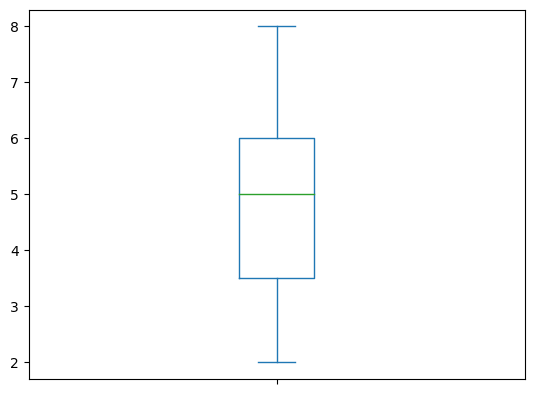

```python
data=pd.Series([2,3,3,4,4,5,5,6,6,8,8])
data.plot(kind='box')
```

```python
df.info()
```

```
<class 'pandas.core.frame.DataFrame'>
RangeIndex: 30 entries, 0 to 29
Data columns (total 2 columns):
 #   Column           Non-Null Count  Dtype
---  ------           --------------  -----
 0   YearsExperience  30 non-null     float64
 1   Salary           30 non-null     float64
dtypes: float64(2)
memory usage: 608.0 bytes
```

**Handling Missing Values**

```python
df = pd.read_csv(r'C:\Users\rahma\Desktop\Data Mining 2024-2025\Section 2\Data Sets\sample.csv')
df.head()
```

|  | Roll No. | Physics | Chemistry | Maths | Computer |
| --- | --- | --- | --- | --- | --- |
| 0 | 1 | 56.0 | 57.0 | 58.0 | 59.0 |
| 1 | 2 | 23.0 | 24.0 | 25.0 | 26.0 |
| 2 | 3 | 89.0 | 25.0 | 26.0 | 27.0 |
| 3 | 4 | 45.0 | 26.0 | 27.0 | 28.0 |
| 4 | 5 | 23.0 | 27.0 | 28.0 | 29.0 |

```python
df.isnull()
```

|  | Roll No. | Physics | Chemistry | Maths | Computer |
| --- | --- | --- | --- | --- | --- |
| 0 | False | False | False | False | False |
| 1 | False | False | False | False | False |
| 2 | False | False | False | False | False |
| 3 | False | False | False | False | False |
| 4 | False | False | False | False | False |
| 5 | False | False | True | False | False |
| 6 | False | False | False | False | False |
| 7 | False | False | False | False | False |
| 8 | False | True | False | False | False |
| 9 | False | False | False | False | False |
| 10 | False | True | False | False | False |
| 11 | False | False | True | False | False |
| 12 | False | False | False | False | False |
| 13 | False | False | True | True | False |
| 14 | False | True | False | False | False |
| 15 | False | False | False | False | False |
| 16 | False | False | False | False | False |
| 17 | False | False | False | False | False |
| 18 | False | False | False | False | False |
| 19 | False | False | False | False | False |
| 20 | False | False | False | False | False |
| 21 | False | False | False | False | False |
| 22 | False | False | False | False | False |
| 23 | False | False | False | False | False |
| 24 | False | False | True | True | False |
| 25 | False | False | False | False | False |
| 26 | False | False | False | False | False |
| 27 | False | False | False | False | True |
| 28 | False | False | False | False | False |
| 29 | False | False | False | False | False |

```python
df.isnull().sum()
```

```
Roll No.     0
Physics      3
Chemistry    4
Maths        2
Computer     1
dtype: int64
```

```python
df.isnull().sum().sum()
```

```
10
```

**Dropping Rows with NaN values**

```python
df.shape
```

```
(30, 5)
```

```python
df2 = df.dropna()     # default axis = 0
```

```python
df2.shape
```

```
(22, 5)
```

**Dropping Columns with NaN values**

```python
df3=df.dropna(axis = 1)
```

```python
type(df3)
```

```
pandas.core.frame.DataFrame
```

```python
df3.shape
```

```
(30, 1)
```

```python
df.dropna(how = 'any')    # if any row value is null then remove that row
```

|  | Roll No. | Physics | Chemistry | Maths | Computer |
| --- | --- | --- | --- | --- | --- |
| 0 | 1 | 56.0 | 57.0 | 58.0 | 59.0 |
| 1 | 2 | 23.0 | 24.0 | 25.0 | 26.0 |
| 2 | 3 | 89.0 | 25.0 | 26.0 | 27.0 |
| 3 | 4 | 45.0 | 26.0 | 27.0 | 28.0 |
| 4 | 5 | 23.0 | 27.0 | 28.0 | 29.0 |
| 6 | 7 | 12.0 | 13.0 | 14.0 | 15.0 |
| 7 | 8 | 78.0 | 14.0 | 15.0 | 16.0 |
| 9 | 10 | 45.0 | 16.0 | 17.0 | 18.0 |
| 12 | 13 | 22.0 | 23.0 | 24.0 | 25.0 |
| 15 | 16 | 44.0 | 44.0 | 44.0 | 44.0 |
| 16 | 17 | 45.0 | 45.0 | 45.0 | 45.0 |
| 17 | 18 | 46.0 | 46.0 | 46.0 | 46.0 |
| 18 | 19 | 47.0 | 47.0 | 47.0 | 47.0 |
| 19 | 20 | 48.0 | 48.0 | 48.0 | 48.0 |
| 20 | 21 | 49.0 | 49.0 | 49.0 | 49.0 |
| 21 | 22 | 50.0 | 50.0 | 50.0 | 50.0 |
| 22 | 23 | 51.0 | 51.0 | 51.0 | 51.0 |
| 23 | 24 | 52.0 | 52.0 | 52.0 | 52.0 |
| 25 | 26 | 54.0 | 33.0 | 33.0 | 54.0 |
| 26 | 27 | 55.0 | 34.0 | 34.0 | 55.0 |
| 28 | 29 | 57.0 | 36.0 | 36.0 | 66.0 |
| 29 | 30 | 58.0 | 37.0 | 37.0 | 43.0 |

```python
df.dropna(how = 'all')    # if all row values is null then remove that row
```

|  | Roll No. | Physics | Chemistry | Maths | Computer |
| --- | --- | --- | --- | --- | --- |
| 0 | 1 | 56.0 | 57.0 | 58.0 | 59.0 |
| 1 | 2 | 23.0 | 24.0 | 25.0 | 26.0 |
| 2 | 3 | 89.0 | 25.0 | 26.0 | 27.0 |
| 3 | 4 | 45.0 | 26.0 | 27.0 | 28.0 |
| 4 | 5 | 23.0 | 27.0 | 28.0 | 29.0 |
| 5 | 6 | 90.0 | NaN | 29.0 | 30.0 |
| 6 | 7 | 12.0 | 13.0 | 14.0 | 15.0 |
| 7 | 8 | 78.0 | 14.0 | 15.0 | 16.0 |
| 8 | 9 | NaN | 15.0 | 16.0 | 17.0 |
| 9 | 10 | 45.0 | 16.0 | 17.0 | 18.0 |
| 10 | 11 | NaN | 17.0 | 18.0 | 19.0 |
| 11 | 12 | 88.0 | NaN | 19.0 | 20.0 |
| 12 | 13 | 22.0 | 23.0 | 24.0 | 25.0 |
| 13 | 14 | 90.0 | NaN | NaN | 42.0 |
| 14 | 15 | NaN | 43.0 | 43.0 | 43.0 |
| 15 | 16 | 44.0 | 44.0 | 44.0 | 44.0 |
| 16 | 17 | 45.0 | 45.0 | 45.0 | 45.0 |
| 17 | 18 | 46.0 | 46.0 | 46.0 | 46.0 |
| 18 | 19 | 47.0 | 47.0 | 47.0 | 47.0 |
| 19 | 20 | 48.0 | 48.0 | 48.0 | 48.0 |
| 20 | 21 | 49.0 | 49.0 | 49.0 | 49.0 |
| 21 | 22 | 50.0 | 50.0 | 50.0 | 50.0 |
| 22 | 23 | 51.0 | 51.0 | 51.0 | 51.0 |
| 23 | 24 | 52.0 | 52.0 | 52.0 | 52.0 |
| 24 | 25 | 53.0 | NaN | NaN | 53.0 |
| 25 | 26 | 54.0 | 33.0 | 33.0 | 54.0 |
| 26 | 27 | 55.0 | 34.0 | 34.0 | 55.0 |
| 27 | 28 | 56.0 | 35.0 | 35.0 | NaN |
| 28 | 29 | 57.0 | 36.0 | 36.0 | 66.0 |
| 29 | 30 | 58.0 | 37.0 | 37.0 | 43.0 |

```python
df.shape
```

```
(30, 5)
```

**Filling the Null Values**

```python
df = pd.read_csv(r'C:\Users\rahma\Desktop\Data Mining 2024-2025\Section 2\Data Sets\sample.csv')
df.head()
```

|  | Roll No. | Physics | Chemistry | Maths | Computer |
| --- | --- | --- | --- | --- | --- |
| 0 | 1 | 56.0 | 57.0 | 58.0 | 59.0 |
| 1 | 2 | 23.0 | 24.0 | 25.0 | 26.0 |
| 2 | 3 | 89.0 | 25.0 | 26.0 | 27.0 |
| 3 | 4 | 45.0 | 26.0 | 27.0 | 28.0 |
| 4 | 5 | 23.0 | 27.0 | 28.0 | 29.0 |

```python
df.isnull().sum()
```

```
Roll No.     0
Physics      3
Chemistry    4
Maths        2
Computer     1
dtype: int64
```

```python
df.fillna(3)
```

|  | Roll No. | Physics | Chemistry | Maths | Computer |
| --- | --- | --- | --- | --- | --- |
| 0 | 1 | 56.0 | 57.0 | 58.0 | 59.0 |
| 1 | 2 | 23.0 | 24.0 | 25.0 | 26.0 |
| 2 | 3 | 89.0 | 25.0 | 26.0 | 27.0 |
| 3 | 4 | 45.0 | 26.0 | 27.0 | 28.0 |
| 4 | 5 | 23.0 | 27.0 | 28.0 | 29.0 |
| 5 | 6 | 90.0 | 3.0 | 29.0 | 30.0 |
| 6 | 7 | 12.0 | 13.0 | 14.0 | 15.0 |
| 7 | 8 | 78.0 | 14.0 | 15.0 | 16.0 |
| 8 | 9 | 3.0 | 15.0 | 16.0 | 17.0 |
| 9 | 10 | 45.0 | 16.0 | 17.0 | 18.0 |
| 10 | 11 | 3.0 | 17.0 | 18.0 | 19.0 |
| 11 | 12 | 88.0 | 3.0 | 19.0 | 20.0 |
| 12 | 13 | 22.0 | 23.0 | 24.0 | 25.0 |
| 13 | 14 | 90.0 | 3.0 | 3.0 | 42.0 |
| 14 | 15 | 3.0 | 43.0 | 43.0 | 43.0 |
| 15 | 16 | 44.0 | 44.0 | 44.0 | 44.0 |
| 16 | 17 | 45.0 | 45.0 | 45.0 | 45.0 |
| 17 | 18 | 46.0 | 46.0 | 46.0 | 46.0 |
| 18 | 19 | 47.0 | 47.0 | 47.0 | 47.0 |
| 19 | 20 | 48.0 | 48.0 | 48.0 | 48.0 |
| 20 | 21 | 49.0 | 49.0 | 49.0 | 49.0 |
| 21 | 22 | 50.0 | 50.0 | 50.0 | 50.0 |
| 22 | 23 | 51.0 | 51.0 | 51.0 | 51.0 |
| 23 | 24 | 52.0 | 52.0 | 52.0 | 52.0 |
| 24 | 25 | 53.0 | 3.0 | 3.0 | 53.0 |
| 25 | 26 | 54.0 | 33.0 | 33.0 | 54.0 |
| 26 | 27 | 55.0 | 34.0 | 34.0 | 55.0 |
| 27 | 28 | 56.0 | 35.0 | 35.0 | 3.0 |
| 28 | 29 | 57.0 | 36.0 | 36.0 | 66.0 |
| 29 | 30 | 58.0 | 37.0 | 37.0 | 43.0 |

```python
df.fillna(2)
```

|  | Roll No. | Physics | Chemistry | Maths | Computer |
| --- | --- | --- | --- | --- | --- |
| 0 | 1 | 56.0 | 57.0 | 58.0 | 59.0 |
| 1 | 2 | 23.0 | 24.0 | 25.0 | 26.0 |
| 2 | 3 | 89.0 | 25.0 | 26.0 | 27.0 |
| 3 | 4 | 45.0 | 26.0 | 27.0 | 28.0 |
| 4 | 5 | 23.0 | 27.0 | 28.0 | 29.0 |
| 5 | 6 | 90.0 | 2.0 | 29.0 | 30.0 |
| 6 | 7 | 12.0 | 13.0 | 14.0 | 15.0 |
| 7 | 8 | 78.0 | 14.0 | 15.0 | 16.0 |
| 8 | 9 | 2.0 | 15.0 | 16.0 | 17.0 |
| 9 | 10 | 45.0 | 16.0 | 17.0 | 18.0 |
| 10 | 11 | 2.0 | 17.0 | 18.0 | 19.0 |
| 11 | 12 | 88.0 | 2.0 | 19.0 | 20.0 |
| 12 | 13 | 22.0 | 23.0 | 24.0 | 25.0 |
| 13 | 14 | 90.0 | 2.0 | 2.0 | 42.0 |
| 14 | 15 | 2.0 | 43.0 | 43.0 | 43.0 |
| 15 | 16 | 44.0 | 44.0 | 44.0 | 44.0 |
| 16 | 17 | 45.0 | 45.0 | 45.0 | 45.0 |
| 17 | 18 | 46.0 | 46.0 | 46.0 | 46.0 |
| 18 | 19 | 47.0 | 47.0 | 47.0 | 47.0 |
| 19 | 20 | 48.0 | 48.0 | 48.0 | 48.0 |
| 20 | 21 | 49.0 | 49.0 | 49.0 | 49.0 |
| 21 | 22 | 50.0 | 50.0 | 50.0 | 50.0 |
| 22 | 23 | 51.0 | 51.0 | 51.0 | 51.0 |
| 23 | 24 | 52.0 | 52.0 | 52.0 | 52.0 |
| 24 | 25 | 53.0 | 2.0 | 2.0 | 53.0 |
| 25 | 26 | 54.0 | 33.0 | 33.0 | 54.0 |
| 26 | 27 | 55.0 | 34.0 | 34.0 | 55.0 |
| 27 | 28 | 56.0 | 35.0 | 35.0 | 2.0 |
| 28 | 29 | 57.0 | 36.0 | 36.0 | 66.0 |
| 29 | 30 | 58.0 | 37.0 | 37.0 | 43.0 |

```python
df.fillna({'Physics':'none', 'Chemistry':0, 'Maths':30})
```

|  | Roll No. | Physics | Chemistry | Maths | Computer |
| --- | --- | --- | --- | --- | --- |
| 0 | 1 | 56.0 | 57.0 | 58.0 | 59.0 |
| 1 | 2 | 23.0 | 24.0 | 25.0 | 26.0 |
| 2 | 3 | 89.0 | 25.0 | 26.0 | 27.0 |
| 3 | 4 | 45.0 | 26.0 | 27.0 | 28.0 |
| 4 | 5 | 23.0 | 27.0 | 28.0 | 29.0 |
| 5 | 6 | 90.0 | 0.0 | 29.0 | 30.0 |
| 6 | 7 | 12.0 | 13.0 | 14.0 | 15.0 |
| 7 | 8 | 78.0 | 14.0 | 15.0 | 16.0 |
| 8 | 9 | none | 15.0 | 16.0 | 17.0 |
| 9 | 10 | 45.0 | 16.0 | 17.0 | 18.0 |
| 10 | 11 | none | 17.0 | 18.0 | 19.0 |
| 11 | 12 | 88.0 | 0.0 | 19.0 | 20.0 |
| 12 | 13 | 22.0 | 23.0 | 24.0 | 25.0 |
| 13 | 14 | 90.0 | 0.0 | 30.0 | 42.0 |
| 14 | 15 | none | 43.0 | 43.0 | 43.0 |
| 15 | 16 | 44.0 | 44.0 | 44.0 | 44.0 |
| 16 | 17 | 45.0 | 45.0 | 45.0 | 45.0 |
| 17 | 18 | 46.0 | 46.0 | 46.0 | 46.0 |
| 18 | 19 | 47.0 | 47.0 | 47.0 | 47.0 |
| 19 | 20 | 48.0 | 48.0 | 48.0 | 48.0 |
| 20 | 21 | 49.0 | 49.0 | 49.0 | 49.0 |
| 21 | 22 | 50.0 | 50.0 | 50.0 | 50.0 |
| 22 | 23 | 51.0 | 51.0 | 51.0 | 51.0 |
| 23 | 24 | 52.0 | 52.0 | 52.0 | 52.0 |
| 24 | 25 | 53.0 | 0.0 | 30.0 | 53.0 |
| 25 | 26 | 54.0 | 33.0 | 33.0 | 54.0 |
| 26 | 27 | 55.0 | 34.0 | 34.0 | 55.0 |
| 27 | 28 | 56.0 | 35.0 | 35.0 | NaN |
| 28 | 29 | 57.0 | 36.0 | 36.0 | 66.0 |
| 29 | 30 | 58.0 | 37.0 | 37.0 | 43.0 |

```python
df
```

|  | Roll No. | Physics | Chemistry | Maths | Computer |
| --- | --- | --- | --- | --- | --- |
| 0 | 1 | 56.0 | 57.0 | 58.0 | 59.0 |
| 1 | 2 | 23.0 | 24.0 | 25.0 | 26.0 |
| 2 | 3 | 89.0 | 25.0 | 26.0 | 27.0 |
| 3 | 4 | 45.0 | 26.0 | 27.0 | 28.0 |
| 4 | 5 | 23.0 | 27.0 | 28.0 | 29.0 |
| 5 | 6 | 90.0 | NaN | 29.0 | 30.0 |
| 6 | 7 | 12.0 | 13.0 | 14.0 | 15.0 |
| 7 | 8 | 78.0 | 14.0 | 15.0 | 16.0 |
| 8 | 9 | NaN | 15.0 | 16.0 | 17.0 |
| 9 | 10 | 45.0 | 16.0 | 17.0 | 18.0 |
| 10 | 11 | NaN | 17.0 | 18.0 | 19.0 |
| 11 | 12 | 88.0 | NaN | 19.0 | 20.0 |
| 12 | 13 | 22.0 | 23.0 | 24.0 | 25.0 |
| 13 | 14 | 90.0 | NaN | NaN | 42.0 |
| 14 | 15 | NaN | 43.0 | 43.0 | 43.0 |
| 15 | 16 | 44.0 | 44.0 | 44.0 | 44.0 |
| 16 | 17 | 45.0 | 45.0 | 45.0 | 45.0 |
| 17 | 18 | 46.0 | 46.0 | 46.0 | 46.0 |
| 18 | 19 | 47.0 | 47.0 | 47.0 | 47.0 |
| 19 | 20 | 48.0 | 48.0 | 48.0 | 48.0 |
| 20 | 21 | 49.0 | 49.0 | 49.0 | 49.0 |
| 21 | 22 | 50.0 | 50.0 | 50.0 | 50.0 |
| 22 | 23 | 51.0 | 51.0 | 51.0 | 51.0 |
| 23 | 24 | 52.0 | 52.0 | 52.0 | 52.0 |
| 24 | 25 | 53.0 | NaN | NaN | 53.0 |
| 25 | 26 | 54.0 | 33.0 | 33.0 | 54.0 |
| 26 | 27 | 55.0 | 34.0 | 34.0 | 55.0 |
| 27 | 28 | 56.0 | 35.0 | 35.0 | NaN |
| 28 | 29 | 57.0 | 36.0 | 36.0 | 66.0 |
| 29 | 30 | 58.0 | 37.0 | 37.0 | 43.0 |

```python
df.fillna(method = 'bfill')
```

|  | Roll No. | Physics | Chemistry | Maths | Computer |
| --- | --- | --- | --- | --- | --- |
| 0 | 1 | 56.0 | 57.0 | 58.0 | 59.0 |
| 1 | 2 | 23.0 | 24.0 | 25.0 | 26.0 |
| 2 | 3 | 89.0 | 25.0 | 26.0 | 27.0 |
| 3 | 4 | 45.0 | 26.0 | 27.0 | 28.0 |
| 4 | 5 | 23.0 | 27.0 | 28.0 | 29.0 |
| 5 | 6 | 90.0 | 13.0 | 29.0 | 30.0 |
| 6 | 7 | 12.0 | 13.0 | 14.0 | 15.0 |
| 7 | 8 | 78.0 | 14.0 | 15.0 | 16.0 |
| 8 | 9 | 45.0 | 15.0 | 16.0 | 17.0 |
| 9 | 10 | 45.0 | 16.0 | 17.0 | 18.0 |
| 10 | 11 | 88.0 | 17.0 | 18.0 | 19.0 |
| 11 | 12 | 88.0 | 23.0 | 19.0 | 20.0 |
| 12 | 13 | 22.0 | 23.0 | 24.0 | 25.0 |
| 13 | 14 | 90.0 | 43.0 | 43.0 | 42.0 |
| 14 | 15 | 44.0 | 43.0 | 43.0 | 43.0 |
| 15 | 16 | 44.0 | 44.0 | 44.0 | 44.0 |
| 16 | 17 | 45.0 | 45.0 | 45.0 | 45.0 |
| 17 | 18 | 46.0 | 46.0 | 46.0 | 46.0 |
| 18 | 19 | 47.0 | 47.0 | 47.0 | 47.0 |
| 19 | 20 | 48.0 | 48.0 | 48.0 | 48.0 |
| 20 | 21 | 49.0 | 49.0 | 49.0 | 49.0 |
| 21 | 22 | 50.0 | 50.0 | 50.0 | 50.0 |
| 22 | 23 | 51.0 | 51.0 | 51.0 | 51.0 |
| 23 | 24 | 52.0 | 52.0 | 52.0 | 52.0 |
| 24 | 25 | 53.0 | 33.0 | 33.0 | 53.0 |
| 25 | 26 | 54.0 | 33.0 | 33.0 | 54.0 |
| 26 | 27 | 55.0 | 34.0 | 34.0 | 55.0 |
| 27 | 28 | 56.0 | 35.0 | 35.0 | 66.0 |
| 28 | 29 | 57.0 | 36.0 | 36.0 | 66.0 |
| 29 | 30 | 58.0 | 37.0 | 37.0 | 43.0 |

```python
df.fillna(method = 'bfill',axis=1)
```

|  | Roll No. | Physics | Chemistry | Maths | Computer |
| --- | --- | --- | --- | --- | --- |
| 0 | 1.0 | 56.0 | 57.0 | 58.0 | 59.0 |
| 1 | 2.0 | 23.0 | 24.0 | 25.0 | 26.0 |
| 2 | 3.0 | 89.0 | 25.0 | 26.0 | 27.0 |
| 3 | 4.0 | 45.0 | 26.0 | 27.0 | 28.0 |
| 4 | 5.0 | 23.0 | 27.0 | 28.0 | 29.0 |
| 5 | 6.0 | 90.0 | 29.0 | 29.0 | 30.0 |
| 6 | 7.0 | 12.0 | 13.0 | 14.0 | 15.0 |
| 7 | 8.0 | 78.0 | 14.0 | 15.0 | 16.0 |
| 8 | 9.0 | 15.0 | 15.0 | 16.0 | 17.0 |
| 9 | 10.0 | 45.0 | 16.0 | 17.0 | 18.0 |
| 10 | 11.0 | 17.0 | 17.0 | 18.0 | 19.0 |
| 11 | 12.0 | 88.0 | 19.0 | 19.0 | 20.0 |
| 12 | 13.0 | 22.0 | 23.0 | 24.0 | 25.0 |
| 13 | 14.0 | 90.0 | 42.0 | 42.0 | 42.0 |
| 14 | 15.0 | 43.0 | 43.0 | 43.0 | 43.0 |
| 15 | 16.0 | 44.0 | 44.0 | 44.0 | 44.0 |
| 16 | 17.0 | 45.0 | 45.0 | 45.0 | 45.0 |
| 17 | 18.0 | 46.0 | 46.0 | 46.0 | 46.0 |
| 18 | 19.0 | 47.0 | 47.0 | 47.0 | 47.0 |
| 19 | 20.0 | 48.0 | 48.0 | 48.0 | 48.0 |
| 20 | 21.0 | 49.0 | 49.0 | 49.0 | 49.0 |
| 21 | 22.0 | 50.0 | 50.0 | 50.0 | 50.0 |
| 22 | 23.0 | 51.0 | 51.0 | 51.0 | 51.0 |
| 23 | 24.0 | 52.0 | 52.0 | 52.0 | 52.0 |
| 24 | 25.0 | 53.0 | 53.0 | 53.0 | 53.0 |
| 25 | 26.0 | 54.0 | 33.0 | 33.0 | 54.0 |
| 26 | 27.0 | 55.0 | 34.0 | 34.0 | 55.0 |
| 27 | 28.0 | 56.0 | 35.0 | 35.0 | NaN |
| 28 | 29.0 | 57.0 | 36.0 | 36.0 | 66.0 |
| 29 | 30.0 | 58.0 | 37.0 | 37.0 | 43.0 |

```python
df.fillna(value=df.mean())
```

|  | Roll No. | Physics | Chemistry | Maths | Computer |
| --- | --- | --- | --- | --- | --- |
| 0 | 1 | 56.000000 | 57.000000 | 58.0 | 59.000000 |
| 1 | 2 | 23.000000 | 24.000000 | 25.0 | 26.000000 |
| 2 | 3 | 89.000000 | 25.000000 | 26.0 | 27.000000 |
| 3 | 4 | 45.000000 | 26.000000 | 27.0 | 28.000000 |
| 4 | 5 | 23.000000 | 27.000000 | 28.0 | 29.000000 |
| 5 | 6 | 90.000000 | 34.884615 | 29.0 | 30.000000 |
| 6 | 7 | 12.000000 | 13.000000 | 14.0 | 15.000000 |
| 7 | 8 | 78.000000 | 14.000000 | 15.0 | 16.000000 |
| 8 | 9 | 52.814815 | 15.000000 | 16.0 | 17.000000 |
| 9 | 10 | 45.000000 | 16.000000 | 17.0 | 18.000000 |
| 10 | 11 | 52.814815 | 17.000000 | 18.0 | 19.000000 |
| 11 | 12 | 88.000000 | 34.884615 | 19.0 | 20.000000 |
| 12 | 13 | 22.000000 | 23.000000 | 24.0 | 25.000000 |
| 13 | 14 | 90.000000 | 34.884615 | 34.5 | 42.000000 |
| 14 | 15 | 52.814815 | 43.000000 | 43.0 | 43.000000 |
| 15 | 16 | 44.000000 | 44.000000 | 44.0 | 44.000000 |
| 16 | 17 | 45.000000 | 45.000000 | 45.0 | 45.000000 |
| 17 | 18 | 46.000000 | 46.000000 | 46.0 | 46.000000 |
| 18 | 19 | 47.000000 | 47.000000 | 47.0 | 47.000000 |
| 19 | 20 | 48.000000 | 48.000000 | 48.0 | 48.000000 |
| 20 | 21 | 49.000000 | 49.000000 | 49.0 | 49.000000 |
| 21 | 22 | 50.000000 | 50.000000 | 50.0 | 50.000000 |
| 22 | 23 | 51.000000 | 51.000000 | 51.0 | 51.000000 |
| 23 | 24 | 52.000000 | 52.000000 | 52.0 | 52.000000 |
| 24 | 25 | 53.000000 | 34.884615 | 34.5 | 53.000000 |
| 25 | 26 | 54.000000 | 33.000000 | 33.0 | 54.000000 |
| 26 | 27 | 55.000000 | 34.000000 | 34.0 | 55.000000 |
| 27 | 28 | 56.000000 | 35.000000 | 35.0 | 38.517241 |
| 28 | 29 | 57.000000 | 36.000000 | 36.0 | 66.000000 |
| 29 | 30 | 58.000000 | 37.000000 | 37.0 | 43.000000 |

```python
df['Physics'].fillna(value=df['Physics'].mean())
```

```
0     56.000000
1     23.000000
2     89.000000
3     45.000000
4     23.000000
5     90.000000
6     12.000000
7     78.000000
8     52.814815
9     45.000000
10    52.814815
11    88.000000
12    22.000000
13    90.000000
14    52.814815
```

[output cut: 16 more lines]

**replace()**

```python
df = pd.read_csv(r'C:\Users\rahma\Desktop\Data Mining 2024-2025\Section 2\Data Sets\sample.csv')
df.head()
```

|  | Roll No. | Physics | Chemistry | Maths | Computer |
| --- | --- | --- | --- | --- | --- |
| 0 | 1 | 56.0 | 57.0 | 58.0 | 59.0 |
| 1 | 2 | 23.0 | 24.0 | 25.0 | 26.0 |
| 2 | 3 | 89.0 | 25.0 | 26.0 | 27.0 |
| 3 | 4 | 45.0 | 26.0 | 27.0 | 28.0 |
| 4 | 5 | 23.0 | 27.0 | 28.0 | 29.0 |

```python
df.replace(to_replace=56, value=30)
```

|  | Roll No. | Physics | Chemistry | Maths | Computer |
| --- | --- | --- | --- | --- | --- |
| 0 | 1 | 30.0 | 57.0 | 58.0 | 59.0 |
| 1 | 2 | 23.0 | 24.0 | 25.0 | 26.0 |
| 2 | 3 | 89.0 | 25.0 | 26.0 | 27.0 |
| 3 | 4 | 45.0 | 26.0 | 27.0 | 28.0 |
| 4 | 5 | 23.0 | 27.0 | 28.0 | 29.0 |
| 5 | 6 | 90.0 | NaN | 29.0 | 30.0 |
| 6 | 7 | 12.0 | 13.0 | 14.0 | 15.0 |
| 7 | 8 | 78.0 | 14.0 | 15.0 | 16.0 |
| 8 | 9 | NaN | 15.0 | 16.0 | 17.0 |
| 9 | 10 | 45.0 | 16.0 | 17.0 | 18.0 |
| 10 | 11 | NaN | 17.0 | 18.0 | 19.0 |
| 11 | 12 | 88.0 | NaN | 19.0 | 20.0 |
| 12 | 13 | 22.0 | 23.0 | 24.0 | 25.0 |
| 13 | 14 | 90.0 | NaN | NaN | 42.0 |
| 14 | 15 | NaN | 43.0 | 43.0 | 43.0 |
| 15 | 16 | 44.0 | 44.0 | 44.0 | 44.0 |
| 16 | 17 | 45.0 | 45.0 | 45.0 | 45.0 |
| 17 | 18 | 46.0 | 46.0 | 46.0 | 46.0 |
| 18 | 19 | 47.0 | 47.0 | 47.0 | 47.0 |
| 19 | 20 | 48.0 | 48.0 | 48.0 | 48.0 |
| 20 | 21 | 49.0 | 49.0 | 49.0 | 49.0 |
| 21 | 22 | 50.0 | 50.0 | 50.0 | 50.0 |
| 22 | 23 | 51.0 | 51.0 | 51.0 | 51.0 |
| 23 | 24 | 52.0 | 52.0 | 52.0 | 52.0 |
| 24 | 25 | 53.0 | NaN | NaN | 53.0 |
| 25 | 26 | 54.0 | 33.0 | 33.0 | 54.0 |
| 26 | 27 | 55.0 | 34.0 | 34.0 | 55.0 |
| 27 | 28 | 30.0 | 35.0 | 35.0 | NaN |
| 28 | 29 | 57.0 | 36.0 | 36.0 | 66.0 |
| 29 | 30 | 58.0 | 37.0 | 37.0 | 43.0 |

```python
df.replace(43, 10000)
```

|  | Roll No. | Physics | Chemistry | Maths | Computer |
| --- | --- | --- | --- | --- | --- |
| 0 | 1 | 56.0 | 57.0 | 58.0 | 59.0 |
| 1 | 2 | 23.0 | 24.0 | 25.0 | 26.0 |
| 2 | 3 | 89.0 | 25.0 | 26.0 | 27.0 |
| 3 | 4 | 45.0 | 26.0 | 27.0 | 28.0 |
| 4 | 5 | 23.0 | 27.0 | 28.0 | 29.0 |
| 5 | 6 | 90.0 | NaN | 29.0 | 30.0 |
| 6 | 7 | 12.0 | 13.0 | 14.0 | 15.0 |
| 7 | 8 | 78.0 | 14.0 | 15.0 | 16.0 |
| 8 | 9 | NaN | 15.0 | 16.0 | 17.0 |
| 9 | 10 | 45.0 | 16.0 | 17.0 | 18.0 |
| 10 | 11 | NaN | 17.0 | 18.0 | 19.0 |
| 11 | 12 | 88.0 | NaN | 19.0 | 20.0 |
| 12 | 13 | 22.0 | 23.0 | 24.0 | 25.0 |
| 13 | 14 | 90.0 | NaN | NaN | 42.0 |
| 14 | 15 | NaN | 10000.0 | 10000.0 | 10000.0 |
| 15 | 16 | 44.0 | 44.0 | 44.0 | 44.0 |
| 16 | 17 | 45.0 | 45.0 | 45.0 | 45.0 |
| 17 | 18 | 46.0 | 46.0 | 46.0 | 46.0 |
| 18 | 19 | 47.0 | 47.0 | 47.0 | 47.0 |
| 19 | 20 | 48.0 | 48.0 | 48.0 | 48.0 |
| 20 | 21 | 49.0 | 49.0 | 49.0 | 49.0 |
| 21 | 22 | 50.0 | 50.0 | 50.0 | 50.0 |
| 22 | 23 | 51.0 | 51.0 | 51.0 | 51.0 |
| 23 | 24 | 52.0 | 52.0 | 52.0 | 52.0 |
| 24 | 25 | 53.0 | NaN | NaN | 53.0 |
| 25 | 26 | 54.0 | 33.0 | 33.0 | 54.0 |
| 26 | 27 | 55.0 | 34.0 | 34.0 | 55.0 |
| 27 | 28 | 56.0 | 35.0 | 35.0 | NaN |
| 28 | 29 | 57.0 | 36.0 | 36.0 | 66.0 |
| 29 | 30 | 58.0 | 37.0 | 37.0 | 10000.0 |

```python
df.replace(to_replace=[50,51,52,53,54,55,56,57,58,59], value= 'A' )
```

|  | Roll No. | Physics | Chemistry | Maths | Computer |
| --- | --- | --- | --- | --- | --- |
| 0 | 1 | A | A | A | A |
| 1 | 2 | 23.0 | 24.0 | 25.0 | 26.0 |
| 2 | 3 | 89.0 | 25.0 | 26.0 | 27.0 |
| 3 | 4 | 45.0 | 26.0 | 27.0 | 28.0 |
| 4 | 5 | 23.0 | 27.0 | 28.0 | 29.0 |
| 5 | 6 | 90.0 | NaN | 29.0 | 30.0 |
| 6 | 7 | 12.0 | 13.0 | 14.0 | 15.0 |
| 7 | 8 | 78.0 | 14.0 | 15.0 | 16.0 |
| 8 | 9 | NaN | 15.0 | 16.0 | 17.0 |
| 9 | 10 | 45.0 | 16.0 | 17.0 | 18.0 |
| 10 | 11 | NaN | 17.0 | 18.0 | 19.0 |
| 11 | 12 | 88.0 | NaN | 19.0 | 20.0 |
| 12 | 13 | 22.0 | 23.0 | 24.0 | 25.0 |
| 13 | 14 | 90.0 | NaN | NaN | 42.0 |
| 14 | 15 | NaN | 43.0 | 43.0 | 43.0 |
| 15 | 16 | 44.0 | 44.0 | 44.0 | 44.0 |
| 16 | 17 | 45.0 | 45.0 | 45.0 | 45.0 |
| 17 | 18 | 46.0 | 46.0 | 46.0 | 46.0 |
| 18 | 19 | 47.0 | 47.0 | 47.0 | 47.0 |
| 19 | 20 | 48.0 | 48.0 | 48.0 | 48.0 |
| 20 | 21 | 49.0 | 49.0 | 49.0 | 49.0 |
| 21 | 22 | A | A | A | A |
| 22 | 23 | A | A | A | A |
| 23 | 24 | A | A | A | A |
| 24 | 25 | A | NaN | NaN | A |
| 25 | 26 | A | 33.0 | 33.0 | A |
| 26 | 27 | A | 34.0 | 34.0 | A |
| 27 | 28 | A | 35.0 | 35.0 | NaN |
| 28 | 29 | A | 36.0 | 36.0 | 66.0 |
| 29 | 30 | A | 37.0 | 37.0 | 43.0 |

```python
df.replace(to_replace=[50,51,52,53], value= ['A', 'B', 'C', 'D'])
```

|  | Roll No. | Physics | Chemistry | Maths | Computer |
| --- | --- | --- | --- | --- | --- |
| 0 | 1 | 56.0 | 57.0 | 58.0 | 59.0 |
| 1 | 2 | 23.0 | 24.0 | 25.0 | 26.0 |
| 2 | 3 | 89.0 | 25.0 | 26.0 | 27.0 |
| 3 | 4 | 45.0 | 26.0 | 27.0 | 28.0 |
| 4 | 5 | 23.0 | 27.0 | 28.0 | 29.0 |
| 5 | 6 | 90.0 | NaN | 29.0 | 30.0 |
| 6 | 7 | 12.0 | 13.0 | 14.0 | 15.0 |
| 7 | 8 | 78.0 | 14.0 | 15.0 | 16.0 |
| 8 | 9 | NaN | 15.0 | 16.0 | 17.0 |
| 9 | 10 | 45.0 | 16.0 | 17.0 | 18.0 |
| 10 | 11 | NaN | 17.0 | 18.0 | 19.0 |
| 11 | 12 | 88.0 | NaN | 19.0 | 20.0 |
| 12 | 13 | 22.0 | 23.0 | 24.0 | 25.0 |
| 13 | 14 | 90.0 | NaN | NaN | 42.0 |
| 14 | 15 | NaN | 43.0 | 43.0 | 43.0 |
| 15 | 16 | 44.0 | 44.0 | 44.0 | 44.0 |
| 16 | 17 | 45.0 | 45.0 | 45.0 | 45.0 |
| 17 | 18 | 46.0 | 46.0 | 46.0 | 46.0 |
| 18 | 19 | 47.0 | 47.0 | 47.0 | 47.0 |
| 19 | 20 | 48.0 | 48.0 | 48.0 | 48.0 |
| 20 | 21 | 49.0 | 49.0 | 49.0 | 49.0 |
| 21 | 22 | A | A | A | A |
| 22 | 23 | B | B | B | B |
| 23 | 24 | C | C | C | C |
| 24 | 25 | D | NaN | NaN | D |
| 25 | 26 | 54.0 | 33.0 | 33.0 | 54.0 |
| 26 | 27 | 55.0 | 34.0 | 34.0 | 55.0 |
| 27 | 28 | 56.0 | 35.0 | 35.0 | NaN |
| 28 | 29 | 57.0 | 36.0 | 36.0 | 66.0 |
| 29 | 30 | 58.0 | 37.0 | 37.0 | 43.0 |

```python
df['Physics'].replace(to_replace=[54,55,56,57], value= ['A', 'B', 'C', 'D'], inplace = True)
```

```python
df['Physics'].replace(to_replace=[54,55,56,57], value= ['A', 'B', 'C', 'D','E'], inplace = True)
```

[output not shown]

```python
df
```

|  | Roll No. | Physics | Chemistry | Maths | Computer |
| --- | --- | --- | --- | --- | --- |
| 0 | 1 | C | 57.0 | 58.0 | 59.0 |
| 1 | 2 | 23.0 | 24.0 | 25.0 | 26.0 |
| 2 | 3 | 89.0 | 25.0 | 26.0 | 27.0 |
| 3 | 4 | 45.0 | 26.0 | 27.0 | 28.0 |
| 4 | 5 | 23.0 | 27.0 | 28.0 | 29.0 |
| 5 | 6 | 90.0 | NaN | 29.0 | 30.0 |
| 6 | 7 | 12.0 | 13.0 | 14.0 | 15.0 |
| 7 | 8 | 78.0 | 14.0 | 15.0 | 16.0 |
| 8 | 9 | NaN | 15.0 | 16.0 | 17.0 |
| 9 | 10 | 45.0 | 16.0 | 17.0 | 18.0 |
| 10 | 11 | NaN | 17.0 | 18.0 | 19.0 |
| 11 | 12 | 88.0 | NaN | 19.0 | 20.0 |
| 12 | 13 | 22.0 | 23.0 | 24.0 | 25.0 |
| 13 | 14 | 90.0 | NaN | NaN | 42.0 |
| 14 | 15 | NaN | 43.0 | 43.0 | 43.0 |
| 15 | 16 | 44.0 | 44.0 | 44.0 | 44.0 |
| 16 | 17 | 45.0 | 45.0 | 45.0 | 45.0 |
| 17 | 18 | 46.0 | 46.0 | 46.0 | 46.0 |
| 18 | 19 | 47.0 | 47.0 | 47.0 | 47.0 |
| 19 | 20 | 48.0 | 48.0 | 48.0 | 48.0 |
| 20 | 21 | 49.0 | 49.0 | 49.0 | 49.0 |
| 21 | 22 | 50.0 | 50.0 | 50.0 | 50.0 |
| 22 | 23 | 51.0 | 51.0 | 51.0 | 51.0 |
| 23 | 24 | 52.0 | 52.0 | 52.0 | 52.0 |
| 24 | 25 | 53.0 | NaN | NaN | 53.0 |
| 25 | 26 | A | 33.0 | 33.0 | 54.0 |
| 26 | 27 | B | 34.0 | 34.0 | 55.0 |
| 27 | 28 | C | 35.0 | 35.0 | NaN |
| 28 | 29 | D | 36.0 | 36.0 | 66.0 |
| 29 | 30 | 58.0 | 37.0 | 37.0 | 43.0 |

```python
df.replace(to_replace='[A-Za-z]',value= 0)
```

|  | Roll No. | Physics | Chemistry | Maths | Computer |
| --- | --- | --- | --- | --- | --- |
| 0 | 1 | C | 57.0 | 58.0 | 59.0 |
| 1 | 2 | 23.0 | 24.0 | 25.0 | 26.0 |
| 2 | 3 | 89.0 | 25.0 | 26.0 | 27.0 |
| 3 | 4 | 45.0 | 26.0 | 27.0 | 28.0 |
| 4 | 5 | 23.0 | 27.0 | 28.0 | 29.0 |
| 5 | 6 | 90.0 | NaN | 29.0 | 30.0 |
| 6 | 7 | 12.0 | 13.0 | 14.0 | 15.0 |
| 7 | 8 | 78.0 | 14.0 | 15.0 | 16.0 |
| 8 | 9 | NaN | 15.0 | 16.0 | 17.0 |
| 9 | 10 | 45.0 | 16.0 | 17.0 | 18.0 |
| 10 | 11 | NaN | 17.0 | 18.0 | 19.0 |
| 11 | 12 | 88.0 | NaN | 19.0 | 20.0 |
| 12 | 13 | 22.0 | 23.0 | 24.0 | 25.0 |
| 13 | 14 | 90.0 | NaN | NaN | 42.0 |
| 14 | 15 | NaN | 43.0 | 43.0 | 43.0 |
| 15 | 16 | 44.0 | 44.0 | 44.0 | 44.0 |
| 16 | 17 | 45.0 | 45.0 | 45.0 | 45.0 |
| 17 | 18 | 46.0 | 46.0 | 46.0 | 46.0 |
| 18 | 19 | 47.0 | 47.0 | 47.0 | 47.0 |
| 19 | 20 | 48.0 | 48.0 | 48.0 | 48.0 |
| 20 | 21 | 49.0 | 49.0 | 49.0 | 49.0 |
| 21 | 22 | 50.0 | 50.0 | 50.0 | 50.0 |
| 22 | 23 | 51.0 | 51.0 | 51.0 | 51.0 |
| 23 | 24 | 52.0 | 52.0 | 52.0 | 52.0 |
| 24 | 25 | 53.0 | NaN | NaN | 53.0 |
| 25 | 26 | A | 33.0 | 33.0 | 54.0 |
| 26 | 27 | B | 34.0 | 34.0 | 55.0 |
| 27 | 28 | C | 35.0 | 35.0 | NaN |
| 28 | 29 | D | 36.0 | 36.0 | 66.0 |
| 29 | 30 | 58.0 | 37.0 | 37.0 | 43.0 |

```python
df.replace('[A-Za-z]', 0, regex = True)
```

|  | Roll No. | Physics | Chemistry | Maths | Computer |
| --- | --- | --- | --- | --- | --- |
| 0 | 1 | 0.0 | 57.0 | 58.0 | 59.0 |
| 1 | 2 | 23.0 | 24.0 | 25.0 | 26.0 |
| 2 | 3 | 89.0 | 25.0 | 26.0 | 27.0 |
| 3 | 4 | 45.0 | 26.0 | 27.0 | 28.0 |
| 4 | 5 | 23.0 | 27.0 | 28.0 | 29.0 |
| 5 | 6 | 90.0 | NaN | 29.0 | 30.0 |
| 6 | 7 | 12.0 | 13.0 | 14.0 | 15.0 |
| 7 | 8 | 78.0 | 14.0 | 15.0 | 16.0 |
| 8 | 9 | NaN | 15.0 | 16.0 | 17.0 |
| 9 | 10 | 45.0 | 16.0 | 17.0 | 18.0 |
| 10 | 11 | NaN | 17.0 | 18.0 | 19.0 |
| 11 | 12 | 88.0 | NaN | 19.0 | 20.0 |
| 12 | 13 | 22.0 | 23.0 | 24.0 | 25.0 |
| 13 | 14 | 90.0 | NaN | NaN | 42.0 |
| 14 | 15 | NaN | 43.0 | 43.0 | 43.0 |
| 15 | 16 | 44.0 | 44.0 | 44.0 | 44.0 |
| 16 | 17 | 45.0 | 45.0 | 45.0 | 45.0 |
| 17 | 18 | 46.0 | 46.0 | 46.0 | 46.0 |
| 18 | 19 | 47.0 | 47.0 | 47.0 | 47.0 |
| 19 | 20 | 48.0 | 48.0 | 48.0 | 48.0 |
| 20 | 21 | 49.0 | 49.0 | 49.0 | 49.0 |
| 21 | 22 | 50.0 | 50.0 | 50.0 | 50.0 |
| 22 | 23 | 51.0 | 51.0 | 51.0 | 51.0 |
| 23 | 24 | 52.0 | 52.0 | 52.0 | 52.0 |
| 24 | 25 | 53.0 | NaN | NaN | 53.0 |
| 25 | 26 | 0.0 | 33.0 | 33.0 | 54.0 |
| 26 | 27 | 0.0 | 34.0 | 34.0 | 55.0 |
| 27 | 28 | 0.0 | 35.0 | 35.0 | NaN |
| 28 | 29 | 0.0 | 36.0 | 36.0 | 66.0 |
| 29 | 30 | 58.0 | 37.0 | 37.0 | 43.0 |

```python
df.replace(to_replace= 30, method = 'ffill')
```

|  | Roll No. | Physics | Chemistry | Maths | Computer |
| --- | --- | --- | --- | --- | --- |
| 0 | 1 | C | 57.0 | 58.0 | 59.0 |
| 1 | 2 | 23.0 | 24.0 | 25.0 | 26.0 |
| 2 | 3 | 89.0 | 25.0 | 26.0 | 27.0 |
| 3 | 4 | 45.0 | 26.0 | 27.0 | 28.0 |
| 4 | 5 | 23.0 | 27.0 | 28.0 | 29.0 |
| 5 | 6 | 90.0 | NaN | 29.0 | 29.0 |
| 6 | 7 | 12.0 | 13.0 | 14.0 | 15.0 |
| 7 | 8 | 78.0 | 14.0 | 15.0 | 16.0 |
| 8 | 9 | NaN | 15.0 | 16.0 | 17.0 |
| 9 | 10 | 45.0 | 16.0 | 17.0 | 18.0 |
| 10 | 11 | NaN | 17.0 | 18.0 | 19.0 |
| 11 | 12 | 88.0 | NaN | 19.0 | 20.0 |
| 12 | 13 | 22.0 | 23.0 | 24.0 | 25.0 |
| 13 | 14 | 90.0 | NaN | NaN | 42.0 |
| 14 | 15 | NaN | 43.0 | 43.0 | 43.0 |
| 15 | 16 | 44.0 | 44.0 | 44.0 | 44.0 |
| 16 | 17 | 45.0 | 45.0 | 45.0 | 45.0 |
| 17 | 18 | 46.0 | 46.0 | 46.0 | 46.0 |
| 18 | 19 | 47.0 | 47.0 | 47.0 | 47.0 |
| 19 | 20 | 48.0 | 48.0 | 48.0 | 48.0 |
| 20 | 21 | 49.0 | 49.0 | 49.0 | 49.0 |
| 21 | 22 | 50.0 | 50.0 | 50.0 | 50.0 |
| 22 | 23 | 51.0 | 51.0 | 51.0 | 51.0 |
| 23 | 24 | 52.0 | 52.0 | 52.0 | 52.0 |
| 24 | 25 | 53.0 | NaN | NaN | 53.0 |
| 25 | 26 | A | 33.0 | 33.0 | 54.0 |
| 26 | 27 | B | 34.0 | 34.0 | 55.0 |
| 27 | 28 | C | 35.0 | 35.0 | NaN |
| 28 | 29 | D | 36.0 | 36.0 | 66.0 |
| 29 | 29 | 58.0 | 37.0 | 37.0 | 43.0 |

```python
df.replace(to_replace= 15, method = 'bfill')
```

|  | Roll No. | Physics | Chemistry | Maths | Computer |
| --- | --- | --- | --- | --- | --- |
| 0 | 1 | C | 57.0 | 58.0 | 59.0 |
| 1 | 2 | 23.0 | 24.0 | 25.0 | 26.0 |
| 2 | 3 | 89.0 | 25.0 | 26.0 | 27.0 |
| 3 | 4 | 45.0 | 26.0 | 27.0 | 28.0 |
| 4 | 5 | 23.0 | 27.0 | 28.0 | 29.0 |
| 5 | 6 | 90.0 | NaN | 29.0 | 30.0 |
| 6 | 7 | 12.0 | 13.0 | 14.0 | 16.0 |
| 7 | 8 | 78.0 | 14.0 | 16.0 | 16.0 |
| 8 | 9 | NaN | 16.0 | 16.0 | 17.0 |
| 9 | 10 | 45.0 | 16.0 | 17.0 | 18.0 |
| 10 | 11 | NaN | 17.0 | 18.0 | 19.0 |
| 11 | 12 | 88.0 | NaN | 19.0 | 20.0 |
| 12 | 13 | 22.0 | 23.0 | 24.0 | 25.0 |
| 13 | 14 | 90.0 | NaN | NaN | 42.0 |
| 14 | 16 | NaN | 43.0 | 43.0 | 43.0 |
| 15 | 16 | 44.0 | 44.0 | 44.0 | 44.0 |
| 16 | 17 | 45.0 | 45.0 | 45.0 | 45.0 |
| 17 | 18 | 46.0 | 46.0 | 46.0 | 46.0 |
| 18 | 19 | 47.0 | 47.0 | 47.0 | 47.0 |
| 19 | 20 | 48.0 | 48.0 | 48.0 | 48.0 |
| 20 | 21 | 49.0 | 49.0 | 49.0 | 49.0 |
| 21 | 22 | 50.0 | 50.0 | 50.0 | 50.0 |
| 22 | 23 | 51.0 | 51.0 | 51.0 | 51.0 |
| 23 | 24 | 52.0 | 52.0 | 52.0 | 52.0 |
| 24 | 25 | 53.0 | NaN | NaN | 53.0 |
| 25 | 26 | A | 33.0 | 33.0 | 54.0 |
| 26 | 27 | B | 34.0 | 34.0 | 55.0 |
| 27 | 28 | C | 35.0 | 35.0 | NaN |
| 28 | 29 | D | 36.0 | 36.0 | 66.0 |
| 29 | 30 | 58.0 | 37.0 | 37.0 | 43.0 |

**loc()**

The loc() function is label based data selecting method which means that we have to pass the name of the row or column which we want to select. This method includes the last element of the range passed in it, unlike iloc(). loc() can accept the boolean data unlike iloc(). Many operations can be performed using the loc() method

```python
df = pd.read_csv(r'C:\Users\rahma\Desktop\Data Mining 2024-2025\Section 2\Data Sets\sample2.csv',
                index_col = ['Roll No.'] )
df.head()
```

| Roll No. | Section | Branch | Physics | Chemistry | Maths | Computer | DOB |
| --- | --- | --- | --- | --- | --- | --- | --- |
| 1 | A | CS | 56.0 | 57.0 | 58.0 | 59.0 | 01-01-2001 |
| 2 | A | ECE | 23.0 | 24.0 | 25.0 | 26.0 | 02-01-2001 |
| 3 | B | MECH | 89.0 | 25.0 | 26.0 | 27.0 | 03-01-2001 |
| 4 | C | MECH | 45.0 | 26.0 | 27.0 | 28.0 | 04-01-2001 |
| 5 | A | CS | 23.0 | 27.0 | 28.0 | 29.0 | 05-01-2001 |

```python
df.loc[1]
```

```
Section               A
Branch               CS
Physics            56.0
Chemistry          57.0
Maths              58.0
Computer           59.0
DOB          01-01-2001
Name: 1, dtype: object
```

```python
df.loc[5]
```

```
Section               A
Branch               CS
Physics            23.0
Chemistry          27.0
Maths              28.0
Computer           29.0
DOB          05-01-2001
Name: 5, dtype: object
```

```python
df.loc[5:8]
```

| Roll No. | Section | Branch | Physics | Chemistry | Maths | Computer | DOB |
| --- | --- | --- | --- | --- | --- | --- | --- |
| 5 | A | CS | 23.0 | 27.0 | 28.0 | 29.0 | 05-01-2001 |
| 6 | A | ECE | 90.0 | NaN | 29.0 | 30.0 | 06-01-2001 |
| 7 | B | CS | 12.0 | 13.0 | 14.0 | 15.0 | 07-01-2001 |
| 8 | C | NaN | 78.0 | 14.0 | 15.0 | 16.0 | 08-01-2001 |

```python
df.loc[5, 'Physics']
```

```
23.0
```

```python
df.loc[5:15, 'Chemistry']
```

```
Roll No.
5     27.0
6      NaN
7     13.0
8     14.0
9     15.0
10    16.0
11    17.0
12     NaN
13    23.0
14     NaN
15    43.0
Name: Chemistry, dtype: float64
```

```python
df.loc[df['Physics']<50]
```

| Roll No. | Section | Branch | Physics | Chemistry | Maths | Computer | DOB |
| --- | --- | --- | --- | --- | --- | --- | --- |
| 2 | A | ECE | 23.0 | 24.0 | 25.0 | 26.0 | 02-01-2001 |
| 4 | C | MECH | 45.0 | 26.0 | 27.0 | 28.0 | 04-01-2001 |
| 5 | A | CS | 23.0 | 27.0 | 28.0 | 29.0 | 05-01-2001 |
| 7 | B | CS | 12.0 | 13.0 | 14.0 | 15.0 | 07-01-2001 |
| 10 | A | CS | 45.0 | 16.0 | 17.0 | 18.0 | 10-01-2001 |
| 13 | A | CS | 22.0 | 23.0 | 24.0 | 25.0 | 13-01-2001 |
| 16 | C | NaN | 44.0 | 44.0 | 44.0 | 44.0 | 16-01-2001 |
| 17 | A | MECH | 45.0 | 45.0 | 45.0 | 45.0 | 17-01-2001 |
| 18 | A | MECH | 46.0 | 46.0 | 46.0 | 46.0 | 18-01-2001 |
| 19 | B | ECE | 47.0 | 47.0 | 47.0 | 47.0 | 19-01-2001 |
| 20 | C | MECH | 48.0 | 48.0 | 48.0 | 48.0 | 20-01-2001 |
| 21 | A | MECH | 49.0 | 49.0 | 49.0 | 49.0 | 21-01-2001 |

```python
df.loc[df['Physics']>80]
```

| Roll No. | Section | Branch | Physics | Chemistry | Maths | Computer | DOB |
| --- | --- | --- | --- | --- | --- | --- | --- |
| 3 | B | MECH | 89.0 | 25.0 | 26.0 | 27.0 | 03-01-2001 |
| 6 | A | ECE | 90.0 | NaN | 29.0 | 30.0 | 06-01-2001 |
| 12 | C | CS | 88.0 | NaN | 19.0 | 20.0 | 12-01-2001 |
| 14 | A | CS | 90.0 | NaN | NaN | 42.0 | 14-01-2001 |

```python
df.loc[df['Physics' ]>80,['Maths','Chemistry']]
```

| Roll No. | Maths | Chemistry |
| --- | --- | --- |
| 3 | 26.0 | 25.0 |
| 6 | 29.0 | NaN |
| 12 | 19.0 | NaN |
| 14 | NaN | NaN |

**iloc()**

The iloc() function is an indexed-based selecting method which means that we have to pass an integer index in the method to select a specific row/column. This method does not include the last element of the range passed in it unlike loc(). iloc() does not accept the boolean data unlike loc().

```python
df.iloc[0]
```

```
Section               A
Branch               CS
Physics            56.0
Chemistry          57.0
Maths              58.0
Computer           59.0
DOB          01-01-2001
Name: 1, dtype: object
```

```python
df.iloc[[0]]
```

| Roll No. | Section | Branch | Physics | Chemistry | Maths | Computer | DOB |
| --- | --- | --- | --- | --- | --- | --- | --- |
| 1 | A | CS | 56.0 | 57.0 | 58.0 | 59.0 | 01-01-2001 |

```python
df.iloc[:,0]
```

```
Roll No.
1     A
2     A
3     B
4     C
5     A
6     A
7     B
8     C
9     A
10    A
11    B
12    C
13    A
14    A
```

[output cut: 17 more lines]

```python
df.iloc[:,1]
```

```
Roll No.
1       CS
2      ECE
3     MECH
4     MECH
5       CS
6      ECE
7       CS
8      NaN
9      ECE
10      CS
11     ECE
12      CS
13      CS
14      CS
```

[output cut: 17 more lines]

```python
df.iloc[0:5, 1]
```

```
Roll No.
1      CS
2     ECE
3    MECH
4    MECH
5      CS
Name: Branch, dtype: object
```

```python
df.iloc[0:5, 1:4]
```

| Roll No. | Branch | Physics | Chemistry |
| --- | --- | --- | --- |
| 1 | CS | 56.0 | 57.0 |
| 2 | ECE | 23.0 | 24.0 |
| 3 | MECH | 89.0 | 25.0 |
| 4 | MECH | 45.0 | 26.0 |
| 5 | CS | 23.0 | 27.0 |

**GroupBy() Function**

```python
df = pd.read_csv(r'C:\Users\rahma\Desktop\ML - winter sem 2425\ML course\Modules_Section\Datasets\sample2.csv')
df.head()
```

|  | Roll No. | Section | Branch | Physics | Chemistry | Maths | Computer | DOB |
| --- | --- | --- | --- | --- | --- | --- | --- | --- |
| 0 | 1 | A | CS | 56.0 | 57.0 | 58.0 | 59.0 | 01-01-2001 |
| 1 | 2 | A | ECE | 23.0 | 24.0 | 25.0 | 26.0 | 02-01-2001 |
| 2 | 3 | B | MECH | 89.0 | 25.0 | 26.0 | 27.0 | 03-01-2001 |
| 3 | 4 | C | MECH | 45.0 | 26.0 | 27.0 | 28.0 | 04-01-2001 |
| 4 | 5 | A | CS | 23.0 | 27.0 | 28.0 | 29.0 | 05-01-2001 |

```python
df.tail()
```

|  | Roll No. | Section | Branch | Physics | Chemistry | Maths | Computer | DOB |
| --- | --- | --- | --- | --- | --- | --- | --- | --- |
| 25 | 26 | A | ECE | 54.0 | 33.0 | 33.0 | 54.0 | 26-01-2001 |
| 26 | 27 | B | CS | 55.0 | 34.0 | 34.0 | 55.0 | 27-01-2001 |
| 27 | 28 | C | CS | 56.0 | 35.0 | 35.0 | NaN | 28-01-2001 |
| 28 | 29 | A | CS | 57.0 | 36.0 | 36.0 | 66.0 | 29-01-2001 |
| 29 | 30 | A | CS | 58.0 | 37.0 | 37.0 | 43.0 | 30-01-2001 |

```python
branch_group = df.groupby(by = 'Branch')
branch_group
```

```
<pandas.core.groupby.generic.DataFrameGroupBy object at 0x0000026C7FF6F7C0>
```

```python
branch_group.groups
```

```
{'CS': [0, 4, 6, 9, 11, 12, 13, 26, 27, 28, 29], 'ECE': [1, 5, 8, 10, 14, 18, 22, 25], 'MECH': [2, 3, 16, 17, 19, 20, 21, 23, 24]}
```

```python
branch_group_section=df.groupby(by = ['Branch', 'Section'])
branch_group_section.groups
```

```
{('CS', 'A'): [0, 4, 9, 12, 13, 28, 29], ('CS', 'B'): [6, 26], ('CS', 'C'): [11, 27], ('ECE', 'A'): [1, 5, 8, 25], ('ECE', 'B'): [10, 14, 18, 22], ('MECH', 'A'): [16, 17, 20, 21, 24], ('MECH', 'B'): [2], ('MECH', 'C'): [3, 19, 23], (nan, 'C'): [7, 15]}
```

```python
for group, data_frame in branch_group_section:
    print(group)

    print(data_frame)
```

```
('CS', 'A')
    Roll No. Section Branch  Physics  Chemistry  Maths  Computer         DOB
0          1       A     CS     56.0       57.0   58.0      59.0  01-01-2001
4          5       A     CS     23.0       27.0   28.0      29.0  05-01-2001
9         10       A     CS     45.0       16.0   17.0      18.0  10-01-2001
12        13       A     CS     22.0       23.0   24.0      25.0  13-01-2001
13        14       A     CS     90.0        NaN    NaN      42.0  14-01-2001
28        29       A     CS     57.0       36.0   36.0      66.0  29-01-2001
29        30       A     CS     58.0       37.0   37.0      43.0  30-01-2001
('CS', 'B')
    Roll No. Section Branch  Physics  Chemistry  Maths  Computer         DOB
6          7       B     CS     12.0       13.0   14.0      15.0  07-01-2001
26        27       B     CS     55.0       34.0   34.0      55.0  27-01-2001
('CS', 'C')
    Roll No. Section Branch  Physics  Chemistry  Maths  Computer         DOB
11        12       C     CS     88.0        NaN   19.0      20.0  12-01-2001
27        28       C     CS     56.0       35.0   35.0       NaN  28-01-2001
('ECE', 'A')
    Roll No. Section Branch  Physics  Chemistry  Maths  Computer         DOB
1          2       A    ECE     23.0       24.0   25.0      26.0  02-01-2001
5          6       A    ECE     90.0        NaN   29.0      30.0  06-01-2001
8          9       A    ECE      NaN       15.0   16.0      17.0  09-01-2001
25        26       A    ECE     54.0       33.0   33.0      54.0  26-01-2001
('ECE', 'B')
    Roll No. Section Branch  Physics  Chemistry  Maths  Computer         DOB
10        11       B    ECE      NaN       17.0   18.0      19.0  11-01-2001
14        15       B    ECE      NaN       43.0   43.0      43.0  15-01-2001
18        19       B    ECE     47.0       47.0   47.0      47.0  19-01-2001
22        23       B    ECE     51.0       51.0   51.0      51.0  23-01-2001
('MECH', 'A')
    Roll No. Section Branch  Physics  Chemistry  Maths  Computer         DOB
16        17       A   MECH     45.0       45.0   45.0      45.0  17-01-2001
17        18       A   MECH     46.0       46.0   46.0      46.0  18-01-2001
20        21       A   MECH     49.0       49.0   49.0      49.0  21-01-2001
21        22       A   MECH     50.0       50.0   50.0      50.0  22-01-2001
24        25       A   MECH     53.0        NaN    NaN      53.0  25-01-2001
('MECH', 'B')
   Roll No. Section Branch  Physics  Chemistry  Maths  Computer         DOB
2         3       B   MECH     89.0       25.0   26.0      27.0  03-01-2001
('MECH', 'C')
    Roll No. Section Branch  Physics  Chemistry  Maths  Computer         DOB
3          4       C   MECH     45.0       26.0   27.0      28.0  04-01-2001
19        20       C   MECH     48.0       48.0   48.0      48.0  20-01-2001
23        24       C   MECH     52.0       52.0   52.0      52.0  24-01-2001
```

**Merge() Function**

```python
df1 = pd.DataFrame({'Roll No.':[1,2,3,4,5], 'Physics':[78,67,34,89,12]})
df1
```

|  | Roll No. | Physics |
| --- | --- | --- |
| 0 | 1 | 78 |
| 1 | 2 | 67 |
| 2 | 3 | 34 |
| 3 | 4 | 89 |
| 4 | 5 | 12 |

```python
df2 = pd.DataFrame({'Roll No.':[1,2,3,4,5,], 'Chemistry':[78,33,39,81,90]})
df2
```

|  | Roll No. | Chemistry |
| --- | --- | --- |
| 0 | 1 | 78 |
| 1 | 2 | 33 |
| 2 | 3 | 39 |
| 3 | 4 | 81 |
| 4 | 5 | 90 |

```python
pd.merge(df1, df2, on = 'Roll No.')
```

|  | Roll No. | Physics | Chemistry |
| --- | --- | --- | --- |
| 0 | 1 | 78 | 78 |
| 1 | 2 | 67 | 33 |
| 2 | 3 | 34 | 39 |
| 3 | 4 | 89 | 81 |
| 4 | 5 | 12 | 90 |

```python
pd.merge(df2, df1, on = 'Roll No.')
```

|  | Roll No. | Chemistry | Physics |
| --- | --- | --- | --- |
| 0 | 1 | 78 | 78 |
| 1 | 2 | 33 | 67 |
| 2 | 3 | 39 | 34 |
| 3 | 4 | 81 | 89 |
| 4 | 5 | 90 | 12 |

```python
pd.merge(df1, df2)   # on - by default intersecting column is taken
```

|  | Roll No. | Physics | Chemistry |
| --- | --- | --- | --- |
| 0 | 1 | 78 | 78 |
| 1 | 2 | 67 | 33 |
| 2 | 3 | 34 | 39 |
| 3 | 4 | 89 | 81 |
| 4 | 5 | 12 | 90 |

```python
df3 = pd.DataFrame({'Roll No.':[1,2,3,6,7], 'Physics':[34,67,34,89,12]})
df4 = pd.DataFrame({'Roll No.':[1,2,3,8,9], 'Chemistry':[34,67,34,89,12]})
```

```python
pd.merge(df3, df4)
```

|  | Roll No. | Physics | Chemistry |
| --- | --- | --- | --- |
| 0 | 1 | 34 | 34 |
| 1 | 2 | 67 | 67 |
| 2 | 3 | 34 | 34 |

```python
pd.merge(df3, df4, how = 'left')
```

|  | Roll No. | Physics | Chemistry |
| --- | --- | --- | --- |
| 0 | 1 | 34 | 34.0 |
| 1 | 2 | 67 | 67.0 |
| 2 | 3 | 34 | 34.0 |
| 3 | 6 | 89 | NaN |
| 4 | 7 | 12 | NaN |

```python
pd.merge(df3, df4, how = 'right')
```

|  | Roll No. | Physics | Chemistry |
| --- | --- | --- | --- |
| 0 | 1 | 34.0 | 34 |
| 1 | 2 | 67.0 | 67 |
| 2 | 3 | 34.0 | 34 |
| 3 | 8 | NaN | 89 |
| 4 | 9 | NaN | 12 |

```python
pd.merge(df3, df4, how = 'outer')
```

|  | Roll No. | Physics | Chemistry |
| --- | --- | --- | --- |
| 0 | 1 | 34.0 | 34.0 |
| 1 | 2 | 67.0 | 67.0 |
| 2 | 3 | 34.0 | 34.0 |
| 3 | 6 | 89.0 | NaN |
| 4 | 7 | 12.0 | NaN |
| 5 | 8 | NaN | 89.0 |
| 6 | 9 | NaN | 12.0 |

```python
pd.merge(df3, df4, how = 'inner')
```

|  | Roll No. | Physics | Chemistry |
| --- | --- | --- | --- |
| 0 | 1 | 34 | 34 |
| 1 | 2 | 67 | 67 |
| 2 | 3 | 34 | 34 |

**append() Function**

```python
df1 = pd.DataFrame({'Roll No.':[1,2,3,4,5], 'Maths':[45,78,45,90,66], 'Physics':[33,67,12,90,44]})
df2 = pd.DataFrame({'Roll No.':[6,7,8,9,10], 'Maths':[78,73,45,90,69], 'Physics':[23,67,88,0,98]})
print(df1)
print(df2)
```

```
   Roll No.  Maths  Physics
0         1     45       33
1         2     78       67
2         3     45       12
3         4     90       90
4         5     66       44
   Roll No.  Maths  Physics
0         6     78       23
1         7     73       67
2         8     45       88
3         9     90        0
4        10     69       98
```

```python
df1.append(df2)
```

|  | Roll No. | Maths | Physics |
| --- | --- | --- | --- |
| 0 | 1 | 45 | 33 |
| 1 | 2 | 78 | 67 |
| 2 | 3 | 45 | 12 |
| 3 | 4 | 90 | 90 |
| 4 | 5 | 66 | 44 |
| 0 | 6 | 78 | 23 |
| 1 | 7 | 73 | 67 |
| 2 | 8 | 45 | 88 |
| 3 | 9 | 90 | 0 |
| 4 | 10 | 69 | 98 |

```python
df2.append(df1)
```

|  | Roll No. | Maths | Physics |
| --- | --- | --- | --- |
| 0 | 6 | 78 | 23 |
| 1 | 7 | 73 | 67 |
| 2 | 8 | 45 | 88 |
| 3 | 9 | 90 | 0 |
| 4 | 10 | 69 | 98 |
| 0 | 1 | 45 | 33 |
| 1 | 2 | 78 | 67 |
| 2 | 3 | 45 | 12 |
| 3 | 4 | 90 | 90 |
| 4 | 5 | 66 | 44 |

```python
df1.append(df2, ignore_index=True)
```

|  | Roll No. | Maths | Physics |
| --- | --- | --- | --- |
| 0 | 1 | 45 | 33 |
| 1 | 2 | 78 | 67 |
| 2 | 3 | 45 | 12 |
| 3 | 4 | 90 | 90 |
| 4 | 5 | 66 | 44 |
| 5 | 6 | 78 | 23 |
| 6 | 7 | 73 | 67 |
| 7 | 8 | 45 | 88 |
| 8 | 9 | 90 | 0 |
| 9 | 10 | 69 | 98 |

```python
df1.append(df2, ignore_index=True, sort=True)
```

|  | Maths | Physics | Roll No. |
| --- | --- | --- | --- |
| 0 | 45 | 33 | 1 |
| 1 | 78 | 67 | 2 |
| 2 | 45 | 12 | 3 |
| 3 | 90 | 90 | 4 |
| 4 | 66 | 44 | 5 |
| 5 | 78 | 23 | 6 |
| 6 | 73 | 67 | 7 |
| 7 | 45 | 88 | 8 |
| 8 | 90 | 0 | 9 |
| 9 | 69 | 98 | 10 |

```python
df1 = pd.DataFrame({'Roll No.':[1,2,3,4,5], 'Chemistry':[45,78,45,90,66], 'Physics':[33,67,12,90,44]})
df2 = pd.DataFrame({'Roll No.':[6,7,8,9,10], 'Maths':[78,73,45,90,69], 'Physics':[23,67,88,0,98]})
print(df1)
print(df2)
```

```
   Roll No.  Chemistry  Physics
0         1         45       33
1         2         78       67
2         3         45       12
3         4         90       90
4         5         66       44
   Roll No.  Maths  Physics
0         6     78       23
1         7     73       67
2         8     45       88
3         9     90        0
4        10     69       98
```

```python
df1.append(df2, ignore_index=True)
```

|  | Roll No. | Chemistry | Physics | Maths |
| --- | --- | --- | --- | --- |
| 0 | 1 | 45.0 | 33 | NaN |
| 1 | 2 | 78.0 | 67 | NaN |
| 2 | 3 | 45.0 | 12 | NaN |
| 3 | 4 | 90.0 | 90 | NaN |
| 4 | 5 | 66.0 | 44 | NaN |
| 5 | 6 | NaN | 23 | 78.0 |
| 6 | 7 | NaN | 67 | 73.0 |
| 7 | 8 | NaN | 88 | 45.0 |
| 8 | 9 | NaN | 0 | 90.0 |
| 9 | 10 | NaN | 98 | 69.0 |

```python
df1 = pd.DataFrame({'Roll No.':[1,2,3,4,5], 'Maths':[45,78,45,90,66], 'Physics':[33,67,12,90,44], 'Chemistry':[56,89,33,12,89]})
df2 = pd.DataFrame({'Roll No.':[6,7,8,9,10], 'Maths':[78,73,45,90,69], 'Physics':[23,67,88,0,98]})
print(df1)
print(df2)
```

```
   Roll No.  Maths  Physics  Chemistry
0         1     45       33         56
1         2     78       67         89
2         3     45       12         33
3         4     90       90         12
4         5     66       44         89
   Roll No.  Maths  Physics
0         6     78       23
1         7     73       67
2         8     45       88
3         9     90        0
4        10     69       98
```

```python
df1.append(df2, ignore_index=True)
```

|  | Roll No. | Maths | Physics | Chemistry |
| --- | --- | --- | --- | --- |
| 0 | 1 | 45 | 33 | 56.0 |
| 1 | 2 | 78 | 67 | 89.0 |
| 2 | 3 | 45 | 12 | 33.0 |
| 3 | 4 | 90 | 90 | 12.0 |
| 4 | 5 | 66 | 44 | 89.0 |
| 5 | 6 | 78 | 23 | NaN |
| 6 | 7 | 73 | 67 | NaN |
| 7 | 8 | 45 | 88 | NaN |
| 8 | 9 | 90 | 0 | NaN |
| 9 | 10 | 69 | 98 | NaN |

**Pivot Table**

```python
df = pd.read_csv(r'C:\Users\rahma\Desktop\Data Mining 2024-2025\Section 2\Data Sets\sample2.csv')
df.head()
```

|  | Roll No. | Section | Branch | Physics | Chemistry | Maths | Computer | DOB |
| --- | --- | --- | --- | --- | --- | --- | --- | --- |
| 0 | 1 | A | CS | 56.0 | 57.0 | 58.0 | 59.0 | 01-01-2001 |
| 1 | 2 | A | ECE | 23.0 | 24.0 | 25.0 | 26.0 | 02-01-2001 |
| 2 | 3 | B | MECH | 89.0 | 25.0 | 26.0 | 27.0 | 03-01-2001 |
| 3 | 4 | C | MECH | 45.0 | 26.0 | 27.0 | 28.0 | 04-01-2001 |
| 4 | 5 | A | CS | 23.0 | 27.0 | 28.0 | 29.0 | 05-01-2001 |

```python
pd.pivot_table(df,index='Branch')
```

| Branch | Chemistry | Computer | Maths | Physics | Roll No. |
| --- | --- | --- | --- | --- | --- |
| CS | 30.888889 | 37.200000 | 30.200 | 51.090909 | 16.000000 |
| ECE | 32.857143 | 35.875000 | 32.750 | 53.000000 | 13.875000 |
| MECH | 42.625000 | 44.222222 | 42.875 | 53.000000 | 17.111111 |

```python
pd.pivot_table(df, index='Branch', aggfunc='sum')
```

| Branch | Chemistry | Computer | Maths | Physics | Roll No. |
| --- | --- | --- | --- | --- | --- |
| CS | 278.0 | 372.0 | 302.0 | 562.0 | 176 |
| ECE | 230.0 | 287.0 | 262.0 | 265.0 | 111 |
| MECH | 341.0 | 398.0 | 343.0 | 477.0 | 154 |

```python
pd.pivot_table(df, index='Branch', aggfunc='count')
```

| Branch | Chemistry | Computer | DOB | Maths | Physics | Roll No. | Section |
| --- | --- | --- | --- | --- | --- | --- | --- |
| CS | 9 | 10 | 11 | 10 | 11 | 11 | 11 |
| ECE | 7 | 8 | 8 | 8 | 5 | 8 | 8 |
| MECH | 8 | 9 | 9 | 8 | 9 | 9 | 9 |

```python
pd.pivot_table(df, index='Branch', aggfunc='max')
```

| Branch | Chemistry | Computer | DOB | Maths | Physics | Roll No. | Section |
| --- | --- | --- | --- | --- | --- | --- | --- |
| CS | 57.0 | 66.0 | 30-01-2001 | 58.0 | 90.0 | 30 | C |
| ECE | 51.0 | 54.0 | 26-01-2001 | 51.0 | 90.0 | 26 | B |
| MECH | 52.0 | 53.0 | 25-01-2001 | 52.0 | 89.0 | 25 | C |

```python
pd.pivot_table(df, index='Branch', columns='Section',aggfunc='count')
```

| Section Branch | Chemistry A | Chemistry B | Chemistry C | Computer A | Computer B | Computer C | DOB A | DOB B | DOB C | Maths A | Maths B | Maths C | Physics A | Physics B | Physics C | Roll No. A | Roll No. B | Roll No. C |
| --- | --- | --- | --- | --- | --- | --- | --- | --- | --- | --- | --- | --- | --- | --- | --- | --- | --- | --- |
| CS | 6.0 | 2.0 | 1.0 | 7.0 | 2.0 | 1.0 | 7.0 | 2.0 | 2.0 | 6.0 | 2.0 | 2.0 | 7.0 | 2.0 | 2.0 | 7.0 | 2.0 | 2.0 |
| ECE | 3.0 | 4.0 | NaN | 4.0 | 4.0 | NaN | 4.0 | 4.0 | NaN | 4.0 | 4.0 | NaN | 3.0 | 2.0 | NaN | 4.0 | 4.0 | NaN |
| MECH | 4.0 | 1.0 | 3.0 | 5.0 | 1.0 | 3.0 | 5.0 | 1.0 | 3.0 | 4.0 | 1.0 | 3.0 | 5.0 | 1.0 | 3.0 | 5.0 | 1.0 | 3.0 |